# Exercícios

## Aula 01

### R como calculadora

1. Calcule o número de ouro no R ($\frac{1 + \sqrt{5}{2}$).
2. O que dá divisão de 1 por 0? E -1 por 0?
3. Quais as diferenças entre `NaN`, `NULL`, `NA` e `Inf`?
4. 1. Tente mentalmente calcular o que dá a conta `5 + 3 * 10 %/% 3 == 15` no R, sem rodar.
5. 2. Adicionando apenas parênteses, faça a expressão acima retornar o resultado contrário.

### Flow Controls

1.a) O que acontece se eu rodar

```r
x <- 4
if(x = 4) {
  'isso aqui apareceu'
}
x
```

Você notou alguma coisa estranha? Como o R se comporta nesse caso?

1.b) Como você modificaria esse código para não dar erro e aparecer a frase ‘isso aqui apareceu’? Obs: Existem duas formas de modificar o código que farão ele funcionar.

2. Escreva a frase (em uma linha)

> 1 elefante(s) incomoda(m) muita gente  
> 2 elefante(s) incomoda(m) incomoda(m) muito mais  
> 3 elefante(s) incomoda(m) muita gente  
> 4 elefante(s) incomoda(m) incomoda(m) incomoda(m) incomoda(m) muito mais

usando `for` ou `while`.

### Funções

```r
x <- letters[1:10]
y <- 10:1

imprime_coisas_legais(x, y)
```

```r
a <- 10
b <- 9
c <- 8
d <- 7
e <- 6
f <- 5
g <- 4
h <- 3
i <- 2
j <- 1
```

## Aula 02

### Estruturas de dados

**1**. O senhor Adalberto é dono de uma loja e, utilizando o R, ele quer criar um cadastro de seus clientes. Para isso, ele está armazenando as informações em uma matriz da seguinte maneira:

```r
cadastro <- matrix(c(NA, NA, NA, NA), nrow = 100, ncol = 4,
                   dimnames = list(NULL, c("Nome", "Idade", "Cidade", "Telefone")))

cadastro[1,] <- c("Maria das Dores", 56, 3025-111, "São Paulo")
cadastro[2,] <- c("José Aníbal", 40, 3333-012, "Santos")
cadastro[3,] <- c("Pedro Silva", 23, 3091-777, "São Paulo")
# ...
```

1. O que faz o argumento `dimnames =`? O que significa o primeiro argumento da lista ser `NULL`?
2. O que vai acontecer se o senhor Adalberto tentar tirar a média da idade dos seus clientes fazendo `mean(cadastro[,2])`? Como ele poderia calcular essa média sem mudar a estrutura do objeto `cadastro`?
3. No lugar de `matrix`, qual seria a melhor estrutura para se utilizar neste caso?

**2**. Por que `0.1 == 0.3/3` retorna `FALSE`?

### Subsetting

**1**. Considere o `data.frame` *diamonds* do R:

1. Como você faria para permutar aleatoriamente as colunas?
2. É possível permutar linhas e colunas simultaneamente em um passo?
3. Como ordenar as colunas do banco de dados em ordem alfabética?
4. Crie uma nova variável no banco de dados que seja 1 se o preço (`price`) for menor 300 e 0 caso contrário.

**2**. Considere o vetor abaixo:

```r
x1 <- 1:8
```

1. Por que a expressao `x1 == c(2,3)` não retorna as posições de `x1` que são iguais a 2 ou 3?
2. O que faz o operador `%in%`?

### Gráficos com o pacote *graphics*

1. Considere o gráfico abaixo:

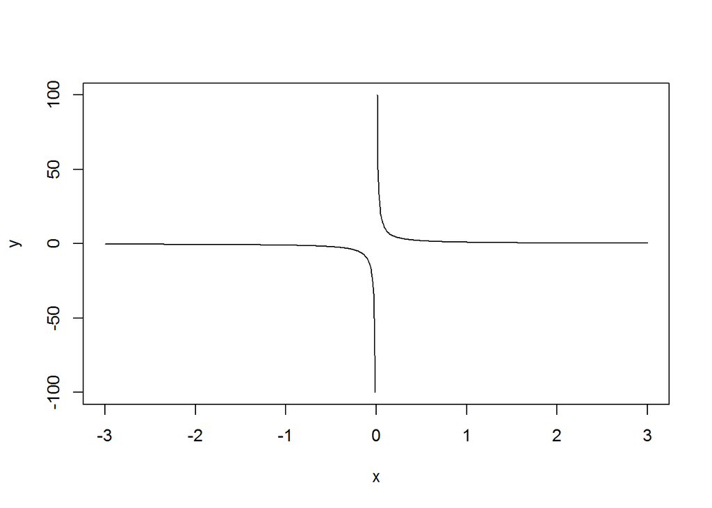

```r
x <- seq(-3, 3, 0.01)
y <- 1/x

plot(x, y, type = "l")
```

1. Altere os limites do eixo x para que o gráfico seja visualizado apenas do -2 ao 2.
2. Acrescente um título ao grafico.
3. Acrescente uma reta vertical pontilhada no ponto x = 0.
4. Acrescente uma legenda ao gráfico.

## Aula 03

## Aula 04

## Aula 05

## Aula 06

## Aula 07

## Aula 08

## Aula 09

## Aula 10

## Aula 11

## Aula 12